# Excercise 2

20 October 2016

### Plots

```r
plot(1:10, main="My scatterplot")
```

[output not shown]

Here are two plots side-by-side

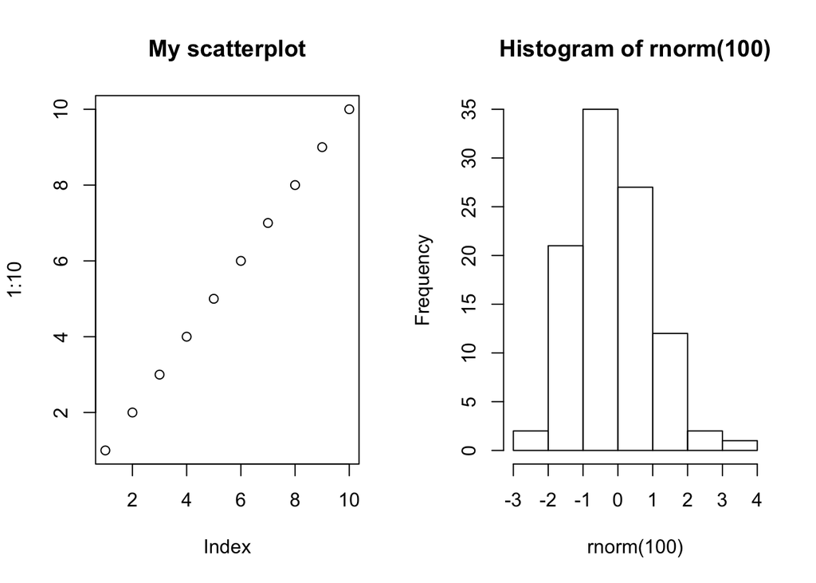

```r
# Create plotting region with one row, two columns
par(mfrow=c(1,2))

# First plot
plot(1:10, main="My scatterplot")

# Second plot
hist(rnorm(100))
```

You can add a name for your chunk after the “r” symbol like this. Note: you shouldn’t have two chunks with the same name!

```r
paste("Hello world")
```

```
## [1] "Hello world"
```

You can set figure widths and heights, either together or separately.

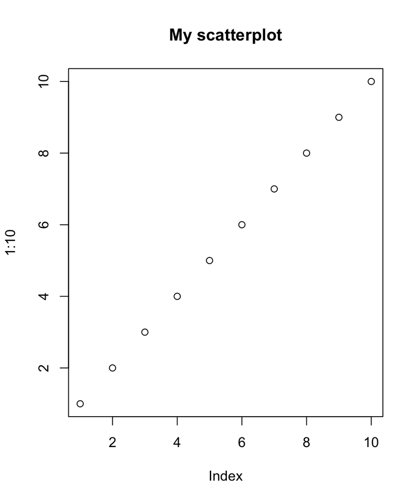

```r
plot(1:10, main="My scatterplot")
```

You can also align the figure to the `centre`, `left` or `right`

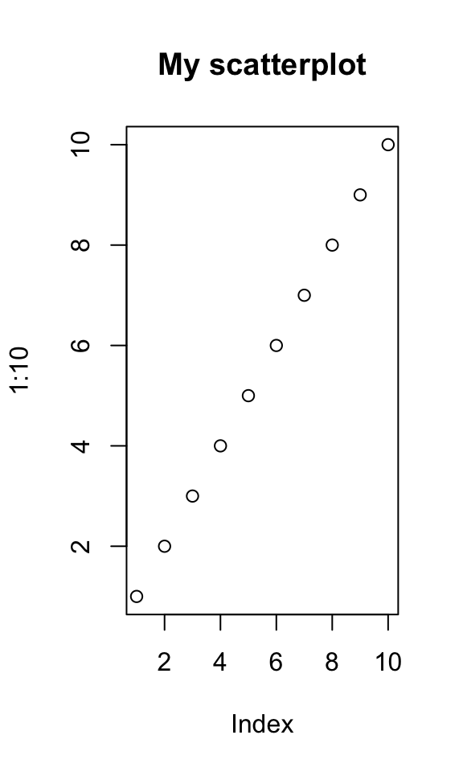

```r
plot(1:10, main="My scatterplot")
```

```r
plot(1:10, main="My scatterplot")
```

[output not shown]

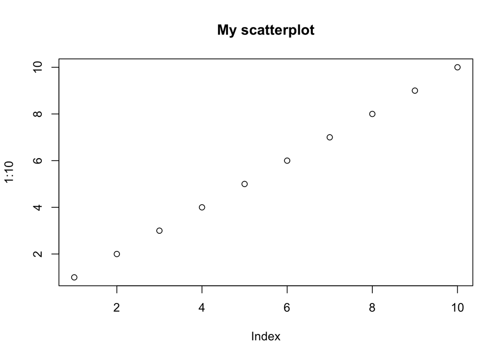

```r
plot(1:10, main="My scatterplot")
```

Figures aren’t saved to file by default. To save figures in a chunk to file set the `fig.path` to the directory to save the path.

```r
plot(1:10, main="My scatterplot")
```

[output not shown]

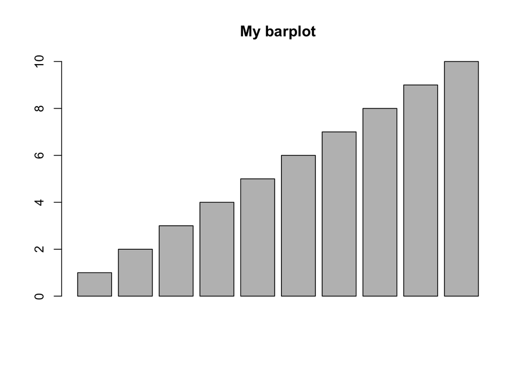

```r
barplot(1:10, main="My barplot")
```

If you set this to `./` the figures will be saved to the directory containing the `.Rnw` file.

```r
plot(1:10, main="My scatterplot")
```

[output not shown]

## Caching

Here is a cached chunk. The first time you run it, it will take ~5 seconds to generate because we are setting the system to sleep for 5 seconds before printing (we are mimicing a computationally intensive function). Any subsequent runs should not take as long, becase the results are cached on your machine.

Play around with it a little. Try setting `cache=FALSE`. Does it run slower?

```r
# Sleep for five second
Sys.sleep(5)
# Print a result
paste("This took me a long time to run!")
```

```
## [1] "This took me a long time to run!"
```